# Practical Machine Learning Project

Michael Kroog

January 24, 2018

## Summary

The purpose of this report is to create a machine learning model which can predict a certain classification of the Unilateral Dumbbell Biceps Curl. The data comes from a human activity recognition study which aims to investigate “how well” an activity was performed. The data comes from this source-http://web.archive.org/web/20161224072740/http:/groupware.les.inf.puc-rio.br/har.

Random Forest, CART, Bagging and Boosting prediction models were selected and compared by accuracy, elapsed time and out of sample error. All the models were run using 10-fold cross validation except for the Random Forest model which doesn’t need CV since about 1/3 of the cases are left out of the bootstrap sample from the original data. Although for a sample size as large are we are using 10-folds maybe be a bit much, but it was select to ensure low bias.

```r
download.file("https://d396qusza40orc.cloudfront.net/predmachlearn/pml-training.csv", "training.csv")
download.file("https://d396qusza40orc.cloudfront.net/predmachlearn/pml-testing.csv", "testing.csv")

training <- read.csv("training.csv")
testing <- read.csv("testing.csv")

library(caret)
library(mlbench)
library(parallel)
library(doParallel)
set.seed(18)

training <- training[,(sapply(training, function(x) sum(is.na(x))) < (nrow(training) *                          0.5)) == TRUE] #subset the columns where the number of NA's are                                           less than 50% of the total observations

#the following removes varaibles with missing values or that aren't related to measurments
training <- training[,-grep("^kurtosis", names(training))]
training <- training[,-grep("^skewness", names(training))]
training <- training[,-grep("^max", names(training))]
training <- training[,-grep("^min", names(training))]
training <- training[,-grep("^amplitude", names(training))]
training <- training[,6:60]

fitControl <- trainControl(method = "cv", number = 10, allowParallel = TRUE) #setting 10                                                                  fold cross validation
cluster <- makeCluster(detectCores() - 1) #enable parallel processing
registerDoParallel(cluster)

#rf
rfTime <- system.time(modFitrf <- train(classe ~ ., method = "rf", data = training))

predRf <- predict(modFitrf, testing)
ooseRf <- 1 - modFitrf$results[2,2]

#rpart
rpartTime <- system.time(modFitrpart <- train(classe ~ ., method ="rpart", data =                                                       training, trControl = fitControl))

predRpart <- predict(modFitrpart, testing)
ooseRpart <- 1 - modFitrpart$results[1,2]

# bagging
bagTime <- system.time(modFitbag <- train(classe ~ ., method = "treebag", data =                                                   training, trControl = fitControl))

predBag <- predict(modFitbag, testing)
ooseBag <- 1 - modFitbag$results[1,2]

#boosting
boostTime <- system.time(modFitgbm <- train(classe ~ ., method = "gbm", data = training,                                              trControl = fitControl, verbose = FALSE))

predBoost <- predict(modFitgbm, testing)
ooseBoost <- 1 - modFitgbm$results[9,5]

stopCluster(cluster)
registerDoSEQ()

# creating data frame of time and accuracy
ModTime <- c(rfTime[3], rpartTime[3], bagTime[3], boostTime[3])
ModAcc <- round(c(modFitrf$results[2,2], modFitrpart$results[1,2],                                       modFitbag$results[1,2], modFitgbm$results[9,5]), 4)
ModType <- c("rf", "rpart", "bag", "boost")
ModOOSE <- round(c(ooseRf[1], ooseRpart[1], ooseBag[1], ooseBoost[1]), 4)
ModResults <- data.frame(ModType, ModAcc, ModTime, ModOOSE)
ModResults
```

```
##   ModType ModAcc ModTime ModOOSE
## 1      rf 0.9975 2453.38  0.0025
## 2   rpart 0.5472    8.81  0.4528
## 3     bag 0.9959   89.12  0.0041
## 4   boost 0.9886  320.55  0.0114
```

## Conclusion

The first plot shows the error rate per number of trees in the Random Forest Model. Even though this model performed 500 trees, it looks like the lowest error plateaus off around 150.

The second plot shows the accuracy per number of iterations in the Boosting model. This model has the most accuracy at around 150 iterations on an interaction depth of 3.

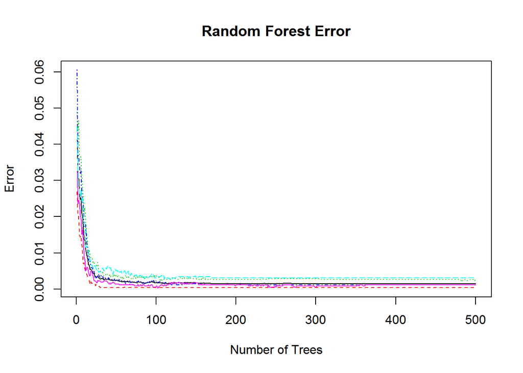

```r
plot(modFitrf$finalModel, ann = FALSE)
title(xlab = "Number of Trees", ylab = "Error", main = "Random Forest Error")
```

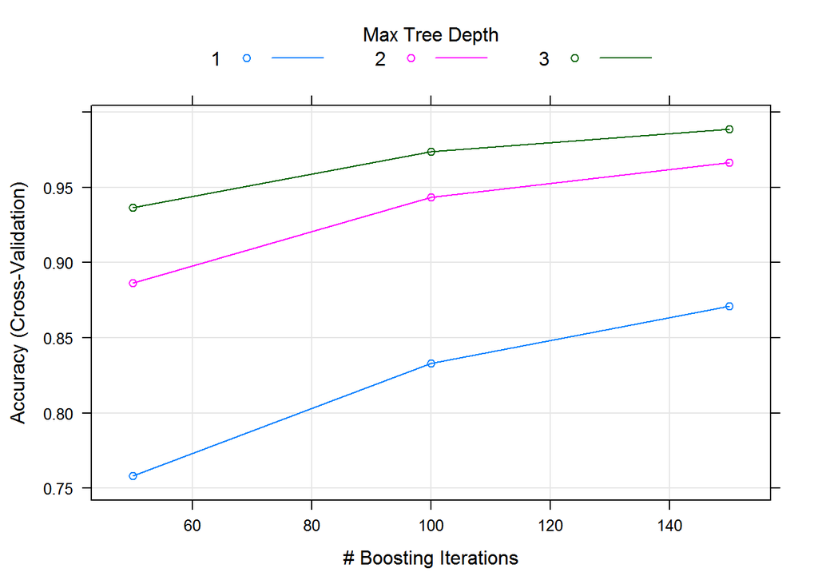

```r
plot(modFitgbm)
```